# Math 495 Project 1

Kristen Bystrom

November 11, 2018

## Data

The dataset I’ve provided describes contains data on personality and on the use of various substances and illegal drugs. There is also gender, age, country, ethnicity and education. I have already converted it to R format.

```r
load("druguse.Rdata")
```

## Question 1

Perform exploratory data analysis. Create visualisations that illustrate the relationship between substance use and the predictor variables.

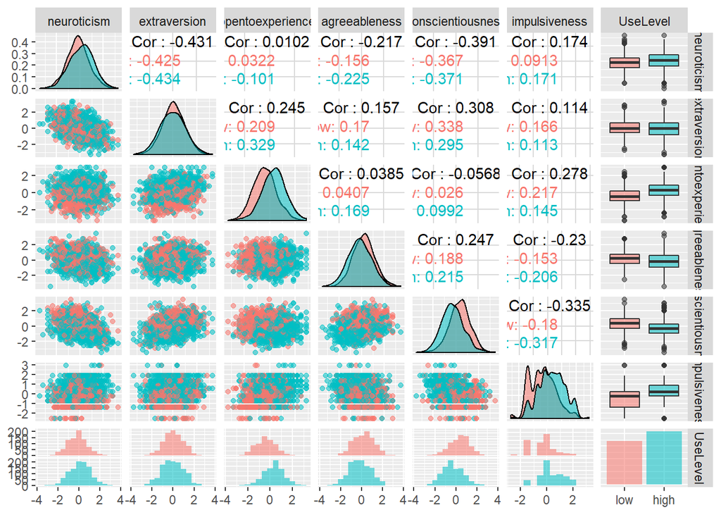

```r
#Create pairwise comparisons for the continuous variables colored by UseLevel
library(GGally)
ggpairs(druguse[,c(6:11, 34)], aes(colour = UseLevel, alpha = 0.03), progress = FALSE,
        lower = list(
          combo = wrap("facethist", binwidth = 0.5))
  )
```

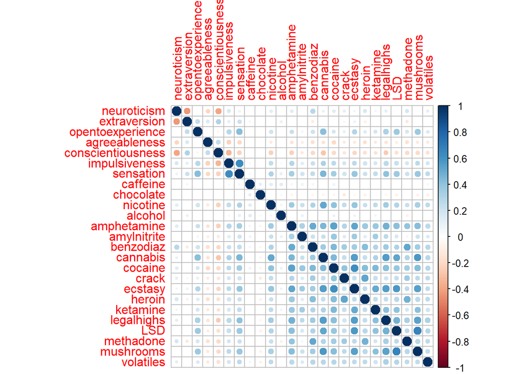

```r
#Create a correlation matrix and leave blank if the correlation coefficient is not significant
library(corrplot)
res1 <- cor.mtest(druguse[,6:30], conf.level = .95)
corrplot(cor(druguse[,6:30]), method = "circle", p.mat = res1$p, insig = "blank")
```

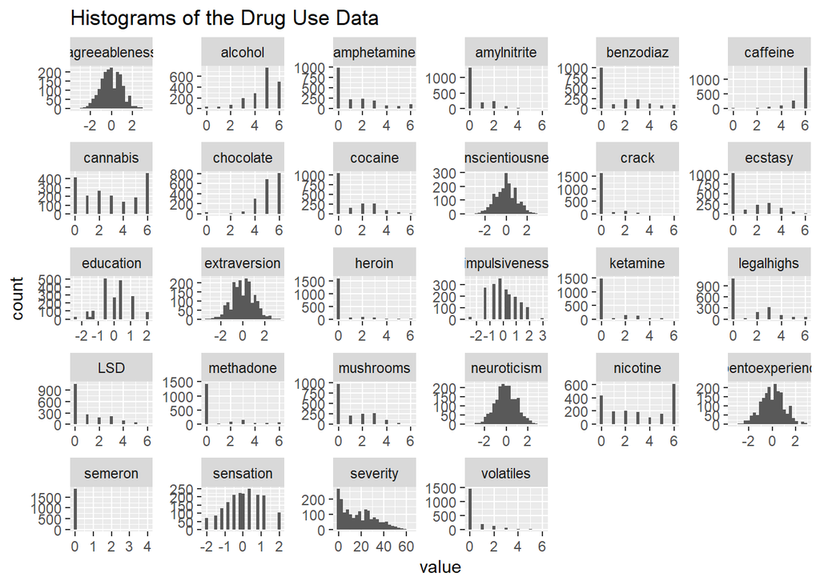

```r
library(tidyr)
#Check the histogram of all predictors, drugs, and response variables
druguse[, c(3,6:31, 33)] %>%
gather() %>%
ggplot(aes(value)) +
    facet_wrap(~ key, scales = "free") +
    geom_histogram(bins = 25) +
  ggtitle("Histograms of the Drug Use Data")
```

## Question 2

### 2.1

Build a classifier that predicts whether an individual’s substance use level will be “high” or “low” based only on the person’s background (age, gender, education, etc) and on the personality measurements.Use only the first 1500 rows to train the model.

```r
#Make agegroup an ordered factor (factor may not be quite ordered, but this seems like not that unreasonable of an assumption)
druguse$agegroup = factor(druguse$agegroup, ordered = TRUE, levels = c("18-24", "25-34", "35-44", "45-54", "55-64", "65+"))

#create test and training data
trainData = druguse[1:1500,]
testData = druguse[1501:1885,]

#build model
model <- glm(UseLevel ~ agegroup + gender + education + country + ethnicity + neuroticism + extraversion + opentoexperience + agreeableness+ conscientiousness+ impulsiveness+ sensation+caffeine+chocolate+nicotine+alcohol,family=binomial(link='logit'),data=trainData)

#see model details
summary(model)
```

```
##
## Call:
## glm(formula = UseLevel ~ agegroup + gender + education + country +
##     ethnicity + neuroticism + extraversion + opentoexperience +
##     agreeableness + conscientiousness + impulsiveness + sensation +
##     caffeine + chocolate + nicotine + alcohol, family = binomial(link = "logit"),
##     data = trainData)
##
## Deviance Residuals:
##     Min       1Q   Median       3Q      Max
## -3.3716  -0.3839   0.1136   0.4335   2.8350
##
## Coefficients:
##                              Estimate Std. Error z value Pr(>|z|)
## (Intercept)                  -3.60793   81.08425  -0.044 0.964509
## agegroup.L                  -10.54710  290.71596  -0.036 0.971059
## agegroup.Q                   -8.72500  265.38616  -0.033 0.973773
## agegroup.C                   -5.38313  181.29335  -0.030 0.976312
## agegroup^4                   -3.09344   91.93278  -0.034 0.973157
## agegroup^5                   -0.93962   30.64486  -0.031 0.975539
## gendermale                    0.99608    0.17900   5.565 2.63e-08 ***
## education                    -0.24197    0.09641  -2.510 0.012076 *
## countryCanada                -0.95985    0.62147  -1.544 0.122470
## countryNewZealand            -0.60832    1.48015  -0.411 0.681084
## countryOther                 -1.25475    0.60282  -2.081 0.037393 *
## countryRepublicofIreland     -2.05125    0.88706  -2.312 0.020755 *
## countryUK                    -2.26286    0.51239  -4.416 1.00e-05 ***
## countryUSA                   -0.10684    0.53838  -0.198 0.842699
## ethnicityBlack               -0.41507    1.18259  -0.351 0.725598
## ethnicityMixed-Black/Asian   15.47208 1225.58311   0.013 0.989928
## ethnicityMixed-White/Asian    1.39396    1.32932   1.049 0.294350
## ethnicityMixed-White/Black    0.66594    1.10933   0.600 0.548301
## ethnicityOther                0.65394    0.94192   0.694 0.487513
## ethnicityWhite                1.14458    0.82535   1.387 0.165508
## neuroticism                  -0.05857    0.10288  -0.569 0.569129
## extraversion                 -0.10974    0.10729  -1.023 0.306348
## opentoexperience              0.58670    0.10499   5.588 2.29e-08 ***
## agreeableness                -0.08247    0.09517  -0.866 0.386229
## conscientiousness            -0.33589    0.10169  -3.303 0.000956 ***
## impulsiveness                -0.01794    0.11046  -0.162 0.870968
## sensation                     0.72502    0.12777   5.674 1.39e-08 ***
## caffeine                      0.09908    0.07911   1.252 0.210407
## chocolate                    -0.14334    0.08028  -1.786 0.074180 .
## nicotine                      0.48670    0.03813  12.763  < 2e-16 ***
## alcohol                      -0.08275    0.06589  -1.256 0.209131
## ---
## Signif. codes:  0 '***' 0.001 '**' 0.01 '*' 0.05 '.' 0.1 ' ' 1
##
## (Dispersion parameter for binomial family taken to be 1)
##
##     Null deviance: 2061.47  on 1499  degrees of freedom
## Residual deviance:  952.71  on 1469  degrees of freedom
## AIC: 1014.7
##
## Number of Fisher Scoring iterations: 15
```

```r
#test if model is "better than nothing"
#anova(model, test = "Chisq")
```

### 2.2

Make predictions on the remaining rows, 1501:1885 and create a table (or confusion matrix) to compare the predictions to the truth. What is the accuracy?

```r
testX = testData[,1:16]
testY = testData[,34]

fitted.results <- predict(model,newdata=testX,type='response')
fitted.results <- factor(ifelse(fitted.results > 0.5,"high","low"), levels = c("low", "high"))

confusionMatrix(data = fitted.results, reference = testY)
```

```
## Confusion Matrix and Statistics
##
##           Reference
## Prediction low high
##       low  153   29
##       high  28  175
##
##                Accuracy : 0.8519
##                  95% CI : (0.8125, 0.8859)
##     No Information Rate : 0.5299
##     P-Value [Acc > NIR] : <2e-16
##
##                   Kappa : 0.7029
##  Mcnemar's Test P-Value : 1
##
##             Sensitivity : 0.8453
##             Specificity : 0.8578
##          Pos Pred Value : 0.8407
##          Neg Pred Value : 0.8621
##              Prevalence : 0.4701
##          Detection Rate : 0.3974
##    Detection Prevalence : 0.4727
##       Balanced Accuracy : 0.8516
##
##        'Positive' Class : low
##
```

The expected accuracy on new data is 85.19%.

## Question 3

### 3.1

Use another method or combination of methods to solve the same problem (namely: predict the UseLevel based on some or all of the predictors in the first 16 columns). If you like, you can make a copy of the data frame in which you convert the non-numerical columns to numerical columns. (Some of the methods we used in the course don’t work for factors or character predictors, like knn).

```r
#build model
model2 <- randomForest(UseLevel ~ agegroup + gender + education + country + ethnicity + neuroticism + extraversion + opentoexperience + agreeableness+ conscientiousness+ impulsiveness+ sensation+caffeine+chocolate+nicotine+alcohol,data=trainData)

#see model details
summary(model2)
```

```
##                 Length Class  Mode
## call               3   -none- call
## type               1   -none- character
## predicted       1500   factor numeric
## err.rate        1500   -none- numeric
## confusion          6   -none- numeric
## votes           3000   matrix numeric
## oob.times       1500   -none- numeric
## classes            2   -none- character
## importance        16   -none- numeric
## importanceSD       0   -none- NULL
## localImportance    0   -none- NULL
## proximity          0   -none- NULL
## ntree              1   -none- numeric
## mtry               1   -none- numeric
## forest            14   -none- list
## y               1500   factor numeric
## test               0   -none- NULL
## inbag              0   -none- NULL
## terms              3   terms  call
```

### 3.2

Estimate how well you would expect your method to perform on new test data.

```r
#Compute Accuracy by making predictions on test data
fitted.results2 <- predict(model2,newdata=testX,type='response')
confusionMatrix(data = fitted.results2, reference = testY)
```

```
## Confusion Matrix and Statistics
##
##           Reference
## Prediction low high
##       low  152   32
##       high  29  172
##
##                Accuracy : 0.8416
##                  95% CI : (0.8012, 0.8766)
##     No Information Rate : 0.5299
##     P-Value [Acc > NIR] : <2e-16
##
##                   Kappa : 0.6823
##  Mcnemar's Test P-Value : 0.7979
##
##             Sensitivity : 0.8398
##             Specificity : 0.8431
##          Pos Pred Value : 0.8261
##          Neg Pred Value : 0.8557
##              Prevalence : 0.4701
##          Detection Rate : 0.3948
##    Detection Prevalence : 0.4779
##       Balanced Accuracy : 0.8415
##
##        'Positive' Class : low
##
```

## Question 4

### 4.1

Create a variable that is “yes” or “no”, representing whether the patient reports that they ever used heroin. Use a random forest to predict whether someone has ever used heroin. For predictors, use the first 16 columns (as before), and now also the other illicit drugs. Think about whether you should use the any, UseLevel or severity columns as predictors.

I did not use any, UseLevel or severity columns, as predictors because my understanding is that they were feature engineered by using the heroin column so there would be an artificially high correlation between those predictors and the heroin indicator.

```r
druguse$horoinIndicator = factor(ifelse(druguse$heroin >0, "yes", "no"), levels = c("no", "yes"))
#create test and training data
trainData3 = druguse[1:1500,]
testData3 = druguse[1501:1885,]

#build model
model3 <- randomForest(horoinIndicator ~ agegroup + gender + education + country + ethnicity + neuroticism + extraversion + opentoexperience + agreeableness+ conscientiousness+ impulsiveness+ sensation+caffeine+chocolate+nicotine+alcohol+amphetamine+ amylnitrite+benzodiaz+cannabis +cocaine+crack+ecstasy+ketamine+legalhighs+LSD+methadone+mushrooms+volatiles+semeron,data=trainData3)

#see model details
summary(model3)
```

```
##                 Length Class  Mode
## call               3   -none- call
## type               1   -none- character
## predicted       1500   factor numeric
## err.rate        1500   -none- numeric
## confusion          6   -none- numeric
## votes           3000   matrix numeric
## oob.times       1500   -none- numeric
## classes            2   -none- character
## importance        30   -none- numeric
## importanceSD       0   -none- NULL
## localImportance    0   -none- NULL
## proximity          0   -none- NULL
## ntree              1   -none- numeric
## mtry               1   -none- numeric
## forest            14   -none- list
## y               1500   factor numeric
## test               0   -none- NULL
## inbag              0   -none- NULL
## terms              3   terms  call
```

```r
#Compute Accuracy by making predictions on test data
testX = testData3[,c(1:23: 25:31)]
testY = testData3[,35]
fitted.results2 <- predict(model3,newdata=testX,type='response')
confusionMatrix(data = fitted.results2, reference = testY)
```

```
## Confusion Matrix and Statistics
##
##           Reference
## Prediction  no yes
##        no  317  29
##        yes   5  34
##
##                Accuracy : 0.9117
##                  95% CI : (0.8788, 0.9381)
##     No Information Rate : 0.8364
##     P-Value [Acc > NIR] : 1.259e-05
##
##                   Kappa : 0.619
##  Mcnemar's Test P-Value : 7.998e-05
##
##             Sensitivity : 0.9845
##             Specificity : 0.5397
##          Pos Pred Value : 0.9162
##          Neg Pred Value : 0.8718
##              Prevalence : 0.8364
##          Detection Rate : 0.8234
##    Detection Prevalence : 0.8987
##       Balanced Accuracy : 0.7621
##
##        'Positive' Class : no
##
```

# 4.2

Based on your interests and your EDA, find another classification, regression or feature selection question that you can ask with this dataset. For example, you could see whether you can predict reported use other drugs. You could create new outcomes like whether someone uses both crack and cocaine, or either crack or cocaine. You could try to predict the level of alcohol consumption based on the personality measurements. There are many interesting options.

Build an appropriate machine learning model to perform this task.

```r
#I am choosing to check if cannabis use alone predicts other illegal sibstances
#I am setting up a linear regression to predict each other substance and comparing the results

illegalList = colnames(druguse[,c(17:19, 21:30)])

#create test and training data
trainData4 = druguse[1:1500,]
testData4 = druguse[1501:1885,]

#build 13 models, one for each illegal drug
models.list = list()
for(i in 1:length(illegalList)){
  models.list[[illegalList[i]]] = glm(paste("cannabis~", illegalList[i]), data = trainData4)
}
```

Why did you choose the method you did? How does it perform? Show the results with a table or plot and an estimate of the loss.

```
## Using  as id variables
## Using  as id variables
```

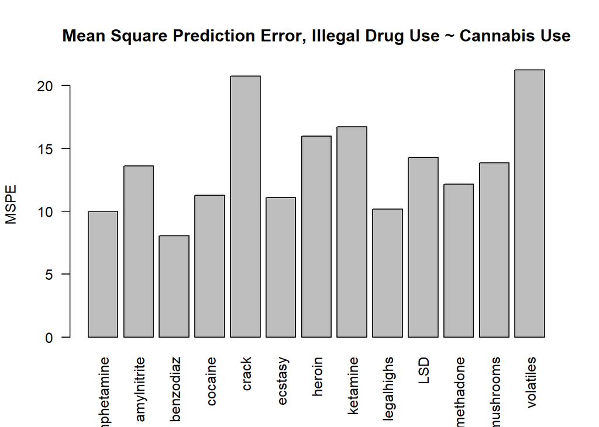

```r
#Compute Accuracy by making predictions on test data for each model in a loop
testX = testData4[,20]
fitted.results.list = list()
MSPE = list()

for(i in illegalList){
  #get predictions
  fitted.results.list[[i]] <- models.list[[i]]$coefficients[1] + testX*models.list[[i]]$coefficients[2]

  #Calculate Mean Squared Prediction Error
  MSPE[[i]] <- mean((testData[,i] - fitted.results.list[[i]]) ^ 2)
}

#Visualize MSPE for predicting each drug based only on cannabis
barplot(melt(data.frame(MSPE))$value, names.arg = melt(data.frame(MSPE))$variable, main = "Mean Square Prediction Error, Illegal Drug Use ~ Cannabis Use", ylab = "MSPE", las = 2)
```

I did not do a test to determine if these differences were statistically significant, however the above plot does tell the beginning of the story and provide justification for further research.